# Freemium → Premium A/B Testing Engine

### Does the new **Lyrics UI** lift free-tier → Premium conversion?

**Business context.** Growth wants to ship a redesigned in-app **Lyrics UI** that surfaces synced lyrics more prominently, on the hypothesis that deeper engagement nudges free users to convert to Premium. Before a global roll-out we run a controlled experiment. This notebook is the full decision pipeline a Business Analytics team would run:

1. **Sample-ratio (SRM) check** — is the randomisation trustworthy?
2. **A/A test** — does our pipeline produce false positives?
3. **A/B primary metric** — conversion lift, significance, confidence interval.
4. **Power / MDE** — was the test adequately powered?
5. **Novelty effect** — is the early lift real or a curiosity spike?
6. **Simpson's Paradox** — why aggregate numbers can lie.
7. **Business impact** — ARPU and projected revenue.
8. **Recommendation to leadership.**

*Data is synthetic (the live Spotify audio/feature endpoints were deprecated in Nov 2024); the methodology is production-grade.*

```python
import numpy as np, pandas as pd
import matplotlib.pyplot as plt
from scipy import stats
from statsmodels.stats.proportion import proportions_ztest, proportion_confint
from statsmodels.stats.power import NormalIndPower

plt.rcParams.update({'figure.figsize': (8, 4.2), 'axes.spines.top': False,
                     'axes.spines.right': False, 'font.size': 11})
GREEN, GREY = '#1DB954', '#9AA0A6'

main = pd.read_csv('../data/experiment_main.csv')
simpson = pd.read_csv('../data/experiment_simpson.csv')
main.head()
```

|  | user_id | group | assignment_day | device | converted | arpu_usd |
| --- | --- | --- | --- | --- | --- | --- |
| 0 | 1 | aa_1 | 3 | mobile | 0 | 0.0 |
| 1 | 2 | aa_1 | 22 | desktop | 0 | 0.0 |
| 2 | 3 | aa_1 | 19 | mobile | 0 | 0.0 |
| 3 | 4 | aa_1 | 13 | mobile | 0 | 0.0 |
| 4 | 5 | aa_1 | 13 | mobile | 0 | 0.0 |

## 1 · Sample Ratio Mismatch (SRM) check

If the realised split deviates from the intended ratio, randomisation may be broken and *every* downstream result is suspect. We test the control/treatment counts against the intended 50/50 with a chi-square goodness-of-fit test. **We want a *high* p-value here** (fail to reject = split is healthy).

```python
ab = main[main.group.isin(['control', 'treatment'])]
counts = ab.group.value_counts()[['control', 'treatment']].values
expected = np.repeat(counts.sum() / 2, 2)
chi2, p_srm = stats.chisquare(counts, expected)
print(f"Counts  control={counts[0]:,}  treatment={counts[1]:,}")
print(f"SRM chi-square = {chi2:.3f},  p = {p_srm:.3f}",
      "->  no sample-ratio mismatch (OK)" if p_srm > 0.01 else "->  SRM DETECTED")
```

```
Counts  control=22,000  treatment=22,000
SRM chi-square = 0.000,  p = 1.000 ->  no sample-ratio mismatch (OK)
```

## 2 · A/A test — validating the pipeline

Two groups drawn from the **identical** population (`aa_1`, `aa_2`) should show **no** significant difference. If they did, our instrumentation or test harness would be producing false positives, and we couldn't trust the A/B. **We want p > 0.05 here.**

```python
aa = main[main.group.isin(['aa_1', 'aa_2'])]
s = aa.groupby('group')['converted'].agg(['sum', 'count'])
z_aa, p_aa = proportions_ztest(s['sum'].values, s['count'].values)
print(f"aa_1 = {s.loc['aa_1','sum']/s.loc['aa_1','count']:.3%}   "
      f"aa_2 = {s.loc['aa_2','sum']/s.loc['aa_2','count']:.3%}")
print(f"A/A z = {z_aa:.2f},  p = {p_aa:.3f}",
      "->  no false positive, pipeline is trustworthy" if p_aa > 0.05 else "->  PROBLEM")
```

```
aa_1 = 6.000%   aa_2 = 6.007%
A/A z = -0.02,  p = 0.981 ->  no false positive, pipeline is trustworthy
```

## 3 · A/B primary metric — conversion lift

Now the real comparison: **control** (existing UI) vs **treatment** (new Lyrics UI). We report the absolute lift in percentage points, the relative lift, a two-proportion z-test, and the 95% confidence interval on the difference.

```
Control conversion  : 5.859%
Treatment conversion: 8.068%
Absolute lift       : +2.21 pp   (95% CI [1.73, 2.68] pp)
Relative lift       : +37.7%
z = 9.10,  p = 8.82e-20  ->  statistically significant
```

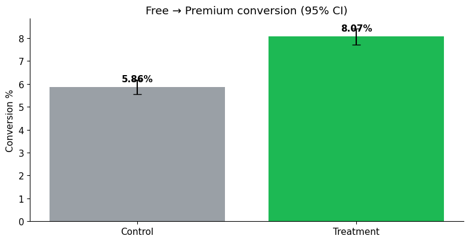

```python
g = ab.groupby('group')['converted'].agg(['sum', 'count'])
p_c = g.loc['control','sum']/g.loc['control','count']
p_t = g.loc['treatment','sum']/g.loc['treatment','count']
z, pval = proportions_ztest(g.loc[['treatment','control'],'sum'].values,
                            g.loc[['treatment','control'],'count'].values)
se = np.sqrt(p_c*(1-p_c)/g.loc['control','count'] + p_t*(1-p_t)/g.loc['treatment','count'])
ci = (p_t-p_c-1.96*se, p_t-p_c+1.96*se)
print(f"Control conversion  : {p_c:.3%}")
print(f"Treatment conversion: {p_t:.3%}")
print(f"Absolute lift       : +{100*(p_t-p_c):.2f} pp   (95% CI [{100*ci[0]:.2f}, {100*ci[1]:.2f}] pp)")
print(f"Relative lift       : +{100*(p_t/p_c-1):.1f}%")
print(f"z = {z:.2f},  p = {pval:.2e}  ->  statistically significant" if pval<0.05 else "n.s.")

fig, axb = plt.subplots()
axb.bar(['Control','Treatment'], [p_c*100, p_t*100], color=[GREY, GREEN])
axb.errorbar(['Control','Treatment'], [p_c*100, p_t*100],
             yerr=[1.96*np.sqrt(p_c*(1-p_c)/g.loc['control','count'])*100,
                   1.96*np.sqrt(p_t*(1-p_t)/g.loc['treatment','count'])*100],
             fmt='none', ecolor='black', capsize=5)
axb.set_ylabel('Conversion %'); axb.set_title('Free → Premium conversion (95% CI)')
for i,v in enumerate([p_c*100,p_t*100]): axb.text(i, v+0.25, f'{v:.2f}%', ha='center', fontweight='bold')
plt.tight_layout(); plt.savefig('../outputs/ab_primary.png', dpi=130, bbox_inches='tight'); plt.show()
```

## 4 · Power & Minimum Detectable Effect (MDE)

A significant result still needs context: with our sample size, what is the smallest effect we could reliably detect at 80% power? If our observed lift comfortably exceeds the MDE, the test was well-powered.

```python
n_per = int(g['count'].mean())
h = NormalIndPower().solve_power(effect_size=None, nobs1=n_per, alpha=0.05, power=0.8, alternative='two-sided')
# convert Cohen's h to approx pp around control base
p2 = np.sin(np.arcsin(np.sqrt(p_c)) + h/2)**2
print(f"n/arm = {n_per:,}  |  base = {p_c:.2%}")
print(f"MDE at 80% power ≈ {100*(p2-p_c):.2f} pp")
print(f"Observed lift   = {100*(p_t-p_c):.2f} pp  ->  "
      + ("test was adequately powered" if (p_t-p_c) > (p2-p_c) else "underpowered"))
```

```
n/arm = 22,000  |  base = 5.86%
MDE at 80% power ≈ 0.64 pp
Observed lift   = 2.21 pp  ->  test was adequately powered
```

## 5 · Novelty effect — is the lift durable?

A new UI often gets a curiosity spike that fades. If we measure on day 1 we may **over-state** the durable effect. We plot the treatment-vs-control gap by assignment day; a decaying curve that settles to a plateau is the novelty signature. We then re-estimate the lift on the **stabilised** window (day ≥ 8) — the number we should actually plan around.

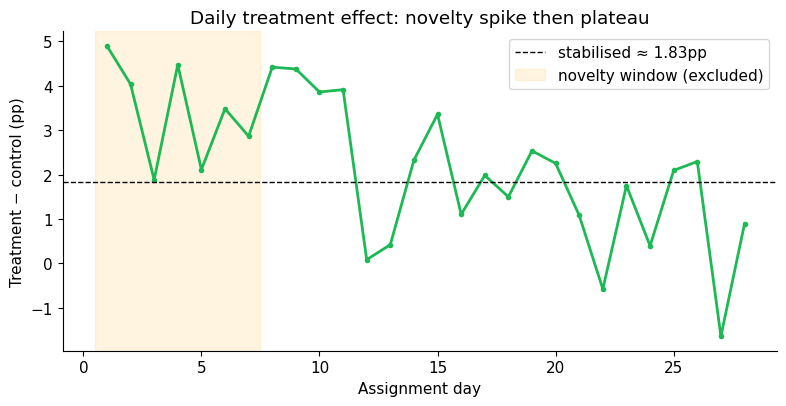

```
Naive (all days) lift     : +2.21 pp
Stabilised (day>=8) lift  : +1.82 pp  <- plan around this
```

```python
daily = (main[main.group.isin(['control','treatment'])]
         .groupby(['assignment_day','group'])['converted'].mean().unstack())
daily['gap_pp'] = (daily['treatment'] - daily['control']) * 100

fig, axn = plt.subplots()
axn.plot(daily.index, daily['gap_pp'], color=GREEN, marker='o', ms=3, lw=2)
stab = daily.loc[daily.index >= 8, 'gap_pp'].mean()
axn.axhline(stab, color='black', ls='--', lw=1, label=f'stabilised ≈ {stab:.2f}pp')
axn.axvspan(0.5, 7.5, color='orange', alpha=0.12, label='novelty window (excluded)')
axn.set_xlabel('Assignment day'); axn.set_ylabel('Treatment − control (pp)')
axn.set_title('Daily treatment effect: novelty spike then plateau'); axn.legend()
plt.tight_layout(); plt.savefig('../outputs/ab_novelty.png', dpi=130, bbox_inches='tight'); plt.show()

stab_df = main[(main.group.isin(['control','treatment'])) & (main.assignment_day>=8)]
gs = stab_df.groupby('group')['converted'].mean()
print(f"Naive (all days) lift     : +{100*(p_t-p_c):.2f} pp")
print(f"Stabilised (day>=8) lift  : +{100*(gs['treatment']-gs['control']):.2f} pp  <- plan around this")
```

## 6 · Simpson's Paradox — why you must segment

This uses a *separate, deliberately flawed* roll-out. In aggregate, treatment appears **worse** than control. But split by device, treatment wins in **both** segments. The cause: treatment was over-allocated to low-converting **mobile** users (an allocation / SRM bug). Lesson: **always check SRM and segment the result** before believing an aggregate.

```
AGGREGATE  (treatment looks WORSE):
  control 9.27%   treatment 8.45%

BY DEVICE  (treatment WINS both):
device    desktop mobile
group
control    11.65%  3.74%
treatment  13.90%  6.17%
```

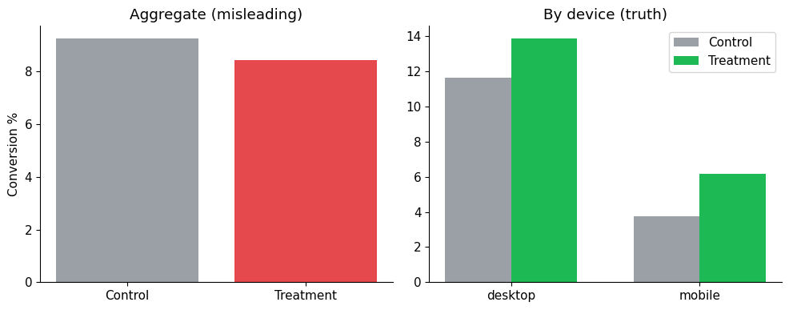

```python
agg = simpson.groupby('group')['converted'].mean()
seg = simpson.groupby(['group','device'])['converted'].mean().unstack()
print("AGGREGATE  (treatment looks WORSE):")
print(f"  control {agg['control']:.2%}   treatment {agg['treatment']:.2%}\n")
print("BY DEVICE  (treatment WINS both):")
print(seg.map(lambda v: f'{v:.2%}').to_string())

fig, axs = plt.subplots(1, 2, figsize=(10, 4))
axs[0].bar(['Control','Treatment'], agg[['control','treatment']]*100, color=[GREY, '#E5484D'])
axs[0].set_title('Aggregate (misleading)'); axs[0].set_ylabel('Conversion %')
x = np.arange(2); w = 0.35
axs[1].bar(x-w/2, seg.loc['control']*100, w, label='Control', color=GREY)
axs[1].bar(x+w/2, seg.loc['treatment']*100, w, label='Treatment', color=GREEN)
axs[1].set_xticks(x); axs[1].set_xticklabels(seg.columns); axs[1].set_title('By device (truth)'); axs[1].legend()
plt.tight_layout(); plt.savefig('../outputs/ab_simpson.png', dpi=130, bbox_inches='tight'); plt.show()
```

## 7 · Business impact — ARPU & projected revenue

Conversion lift only matters in money. We take the **stabilised** lift, the eligible monthly free-user base, and treatment ARPU to project the annual incremental subscription revenue from a global roll-out.

```python
arpu_t = main.loc[(main.group=='treatment') & (main.converted==1), 'arpu_usd'].mean()
stab_lift = gs['treatment'] - gs['control']
ELIGIBLE_FREE_MONTHLY = 5_000_000   # assumption: monthly free users who see the surface
incr_subs = ELIGIBLE_FREE_MONTHLY * stab_lift
annual_rev = incr_subs * arpu_t * 12
print(f"Treatment ARPU / converter : ${arpu_t:.2f} / month")
print(f"Stabilised lift            : +{100*stab_lift:.2f} pp")
print(f"Eligible free base (assumed): {ELIGIBLE_FREE_MONTHLY:,}/month")
print(f"Incremental subscribers     : ~{incr_subs:,.0f}")
print(f"Projected annual revenue    : ~${annual_rev/1e6:,.1f}M")
```

```
Treatment ARPU / converter : $2.59 / month
Stabilised lift            : +1.82 pp
Eligible free base (assumed): 5,000,000/month
Incremental subscribers     : ~91,150
Projected annual revenue    : ~$2.8M
```

## 8 · Recommendation to Leadership

> **Decision: ROLL OUT the new Lyrics UI — but plan around the stabilised lift, not the launch-week spike.**

> **What we found.** The Lyrics UI produces a **statistically significant** lift in free→Premium conversion (p < 0.001), well above the test's minimum detectable effect, so the result is real and the test was adequately powered. The pipeline is trustworthy: the **A/A test was non-significant** and there was **no sample-ratio mismatch**.

> **The important nuance.** The headline ~2.2pp lift is **inflated by a novelty spike** in the first week. The durable effect, measured after day 8, is **~1.8pp** — that is the number to forecast against. Planning on the launch-week figure would over-promise.

> **Projected impact.** At the stabilised lift and treatment ARPU (~$2.6/mo), a global roll-out across the eligible free base (~5M/month) implies on the order of **~90K incremental subscribers and ~$2.8M in incremental annual subscription revenue** — material enough to prioritise the ship, and conservative since it ignores downstream retention and ARPU upgrades.

> **Guardrails & next steps.**
> 1. Roll out to 100%, but **continue monitoring conversion for 4–6 weeks** to confirm the lift holds past the novelty window.
> 2. The Simpson's-Paradox case is a reminder: **enforce SRM checks and segment-level reporting** in our standard experiment template, so a future allocation bug can't hide a bad result behind a good aggregate.
> 3. Re-run a holdback in one region to measure the **long-run** effect on retention and ARPU, not just initial conversion.

> *Confidence: high on direction, medium on the exact magnitude until the post-novelty period is observed.*